# Solução - Tarefa 01

Gabriel Carvalho Freitas RA: 155421

## Exercício 01

Objetivo Geral: Usar o método da inversão para gerar números aleatórios segundo uma distribuição exponencial com parâmetro $\lambda$.

Se $X \sim Exp(\lambda)$, a sua função densidade de probabilidade é dada por
$$f_X(x) = \lambda e^{-\lambda x} I_{[0,\infty]}(x)$$
e sua distribuição acumulada é portanto,
$$F_X(x) = 1-e^{-\lambda x} I_{[0,\infty]}(x).$$

Essa função pode ser fácilmente invertida, e sua inversa é dada pela seguinte expressão:
$$F_X^{-1}(x) = -\dfrac{ln(1-x)}{\lambda}.$$

Sendo assim, podemos gerar variáveis aleatórias $U \sim U(0,1)$ e usar o método da inversão para gerar exponencias com parâmetro lâmbda.

A função `rexp2` será a geradora destes dados e é definida como segue:

```r
rexp2 = function(n, lambda){
  gerad = runif(n)
  VAexp = -log(1-gerad)/lambda
  return(VAexp)
}
```

### Adicione um exemplo de geração de dados.

Como exemplo, vamos gerar $10000$ observações de uma exponencial com parâmetro $\lambda = 5$.

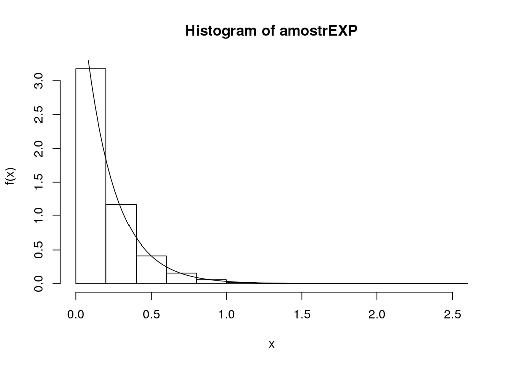

```r
amostrEXP = rexp2(10000,5)
hist(amostrEXP, xlab="x",ylab="f(x)", freq=FALSE)
curve(5*exp(-5*x), add=TRUE)
```

Note que o gráfico indica fortemente que os dados gerados realmente seguem uma distribuição exponencial. Mas vamos produzir um teste estatístico para de fato testar isso.

Podemos usar o teste Chi-Quadrado, contando o número de elementos da amostra que caem dentro de cada intervalo interquartilico teorico e comparando esse número com o esperado da distribuição teorica.

A distribuição usada será a mesma do exemplo de geração, $n=10000$ e $\lambda = 5$ Os quartis teóricos são dados por:

```r
q1 = qexp(0.25,5)
q2 = qexp(0.50,5)
q3 = qexp(0.75,5)

quartisEXP = c(0,q1,q2,q3,Inf)
```

Para contar quantas observações da nossa amostra tem em cada intervalo, fazemos:

```r
gab = cut(amostrEXP,quartisEXP, include.lowest = TRUE)
obsEXP = as.integer(table(gab))
obsEXP
```

```
## [1] 2563 2542 2479 2416
```

E o valor esperado em cada intervalo é dado pelo vetor:

```r
espEXP = rep(1/4,4)*10000
espEXP
```

```
## [1] 2500 2500 2500 2500
```

Logo, aplicando o teste Chi-Quadrado:

```r
chisq.test(cbind(obsEXP,espEXP))
```

```
##
##  Pearson's Chi-squared test
##
## data:  cbind(obsEXP, espEXP)
## X-squared = 2.6577, df = 3, p-value = 0.4475
```

Como obtemos um p-valor muito alto (maior que 0,05) não temos evidência pra rejetiar a hipotese nula de que os dados são gerados por um exponencial $\lambda = 5$

## Exercício 02

Objetivo Geral: Usar o método da inversão para gerar números aleatórios segundo uma distribuição de poisson com parâmetro $\lambda$.

Aqui, como temos uma distribuição discreta, vamos usar o seguinte algoritmo para gerar números da distribuição desejada:

Geramos uma observação $u$ de uma variável aleatória $U \sim U(0,1)$. Seja $x=0$, fazemos então $p=F_X(0)$.

1. Se u $\leq$ p, geramos uma observação de $X=i, i={0,1,2,...}$.
2. Se $u>p$, faça $p=\frac{e^{-\lambda}\lambda^x}{x!}+p$ e $x=x+1$ e volte para o passo 1.

A função `rpois2` será a geradora destes dados e é definida como segue:

```r
rpois2 = function(n, lambda){
  amostrPOI = rep(0,n)
  for(i in 1:n){
    x=0
    p = exp(-lambda)*lambda^x/factorial(x)
    amUN = runif(1)
    while(amUN > p){
      x=x+1
      p = p+(exp(-lambda)*lambda^x/factorial(x))
    }
    amostrPOI[i] = x
  }
  return(amostrPOI)
}
```

### Adicione um exemplo de geração de dados.

Vamos gerar $10000$ números aleatórios usando nossa função com $\lambda=5$.

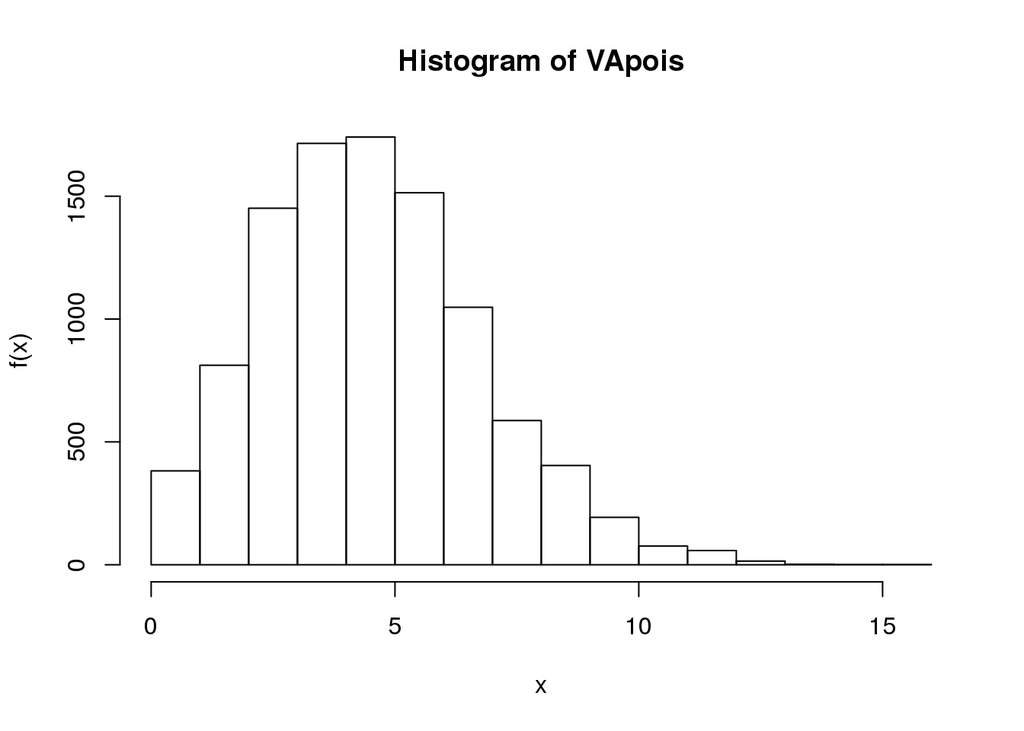

```r
VApois = rpois2(10000,5)
hist(VApois, xlab="x",ylab="f(x)")
```

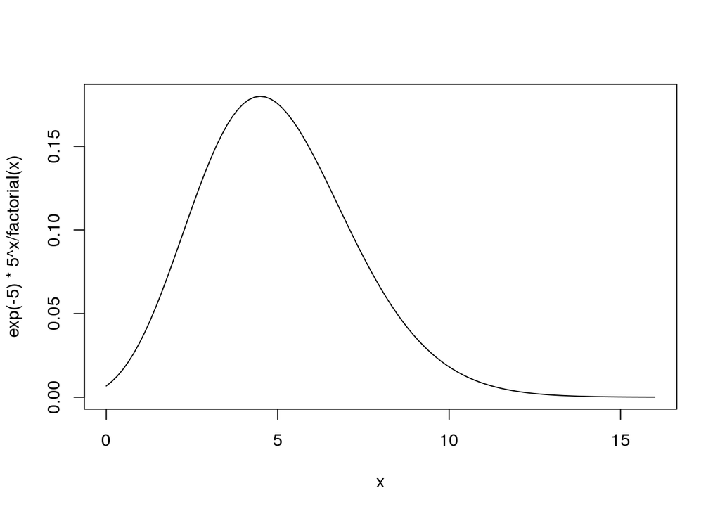

```r
curve(exp(-5)*5^x/factorial(x), add="TRUE")
```

Percebe-se que pelos gráficos a geração realmente funcionou. Porém, vamos realizar um teste para ver se isso é confirmado.

Assim como no exercício 1, usaremos o teste de Chi-Quadrado. Os quartis teoricos são dados por

```r
q1p = qpois(0.25,5)
q2p = qpois(0.50,5)
q3p = qpois(0.75,5)
q4p = qpois(1,5)
quartisPOI = c(0,q1p,q2p,q3p,q4p)
```

Agora, vamos contar quantos dados da nossa amostra cairam nos intervalos de fato

```r
pobs = cut(VApois,quartisPOI, include.lowest = TRUE)
obsPOI = as.integer(table(pobs))
```

Além disso, como estamos usando uma ditribuição discreta, vamos calcular o esperado de uma forma um pouco mais prática, fazendo o seguinte:

```r
espPOI1 = ppois(q1p,5)
espPOI2 = ppois(q2p,5)-ppois(q1p,5)
espPOI3 = ppois(q3p,5)-ppois(q2p,5)
espPOI4 = ppois(q4p,5)-ppois(q3p,5)
espPOI = c(espPOI1,espPOI2,espPOI3,espPOI4)*10000
```

Agora, finalmente aplicando o teste:

```r
chisq.test(cbind(obsPOI,espPOI))
```

```
##
##  Pearson's Chi-squared test
##
## data:  cbind(obsPOI, espPOI)
## X-squared = 1.3242, df = 3, p-value = 0.7234
```

Como obtemos novamente um p-valor muito alto, ou seja, maior que 0,05, não rejeitamos a hipotese nula de que os dados de fato geram uma distribuição de Poisson.

## Exercício 03

Objetivo Geral: Usar o método da rejeição para gerar números aleatórios segundo uma distribuição normal com parâmetros $(\mu, \sigma^2)$.

Como queremos gerar números aleatórios segundo uma distribuição normal com parâmetros $(\mu,\sigma^2)$, podemos simplismente gerar números aleatórios segunda uma distribuição normal $(0,1)$ e fazer a transformação $\sigma x + \mu$, que teremos uma normal com os parâmetros desejados.

Primeiramente, para usar o método da rejeição, precisamos saber gerar números segundo uma distribuição exponencial dupla. Se $X$ tem distribuição exponencial dupla, então
$$f_X(x) = \dfrac{1}{2}e^{-|x|}.$$
Mas, podemos também escrever essa densidade da seguinte maneira:
$$f_X(x) = p_1 f_1(x) + p_2f_2(x).$$
Onde $p_1$ é a probabilidade de $X$ ser menor que zero e $f_1(x)$ é uma densiade equivalente a distribuição nesse intervalo e $p_2$ é a probabiliadde de $X$ ser maior que zero e $f_1(x)$ é uma densidade equivalente a distribuição para esse intervalo. Nesse caso, temos
$$f_X(x) = 0.5 e^{x}I_{[-\infty,0]}(x) + 0.5 e^{-x}I_{[0,\infty]}(x).$$
Ou seja, $f_1(x) = e^{x}I_{[-\infty,0]}(x)$ e $f_2(X) = e^{-x}I_{[0,\infty]}(x)$.

Mas, temos então que
$$F_1(x) = e^x$$
e
$$F_2(x) = 1- e^x.$$

```r
rdexp = function(n){
  u_1 = runif(n)
  u_2 = runif(n)
  VAexdp = rep(0,n)
  for(i in 1:n){
    if(u_1[i] < 1/2){
      VAexdp[i]=log(u_2[i])
    }
    else{
      VAexdp[i]=-log(1-u_2[i])
    }
  }
  return(VAexdp)
}
```

[figure not shown]

Agora, para a geração da normal, perceba que $\dfrac{f(t)}{g(t)} < 2$ onde $f(t)$ é a densidade da normal e $g(t)$ é a densidade da exponencial dupla. Sendo assim, basta seguir o roteiro do metodo de rejeição: 1. Simular uma amostra $y$ a partir de $g$ 2. Simular $u \sim U(0,1)$ 3. Se $u<\dfrac{f(y)}{g(y)2}$, então $x=y$. Caso contrário, retorne para o passo 1.

A função `rnorm2` será a geradora destes dados e é definida como segue:

```r
rnorm2 = function(n, mu, sigma2){
  amstrNOR = rep(0,n)
  cont=1
  while(cont < n+1){
    expd=rdexp(1)
    u=runif(1)
    if(u < f(expd)/(2*g(expd))){
      amstrNOR[cont] = expd
      cont = cont + 1
    }
  }
  norm = sqrt(sigma2)*amstrNOR + mu
  return(norm)
}
```

### Adicione um exemplo de geração de dados.

Gerando $10000$ numeros segundo distribuição normal $(2,4)$:

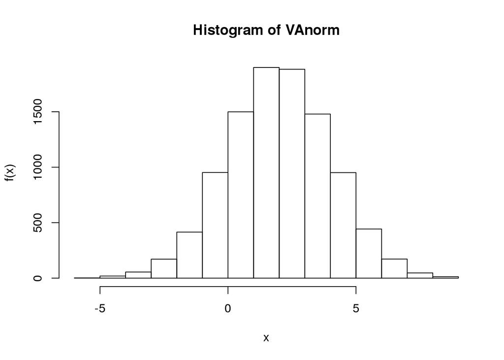

```r
VAnorm=rnorm2(10000,2,4)
hist(VAnorm,xlab="x",ylab="f(x)")
```

De fato o histograma lembda a distribuição normal. Agora, vamos testar se realmente é atráves do teste Chi-Quadrado já usado anteriormente.

Os quartis teoricos são:

```r
q1n = qnorm(0.25,2,2)
q2n = qnorm(0.5,2,2)
q3n = qnorm(0.75,2,2)

quartisNOR = c(-Inf, q1n,q2n,q3n, Inf)
```

Contando quantos valores da nossa amostra realmente estão no que é esperado, comparando com o esperado e fazendo o teste, temos

```r
cobsNOR = cut(VAnorm,quartisNOR,include.lowest = TRUE)
obsNOR = as.integer(table(cobsNOR))
espNOR = rep(1/4,4)*10000
chisq.test(cbind(obsNOR,espNOR))
```

```
##
##  Pearson's Chi-squared test
##
## data:  cbind(obsNOR, espNOR)
## X-squared = 0.1871, df = 3, p-value = 0.9796
```

E como temos um p-valor muito alto, de fato não temos evidência para rejeitar que os dados são provenientes de uma distribuição normal.